# Tracegram analysis

Stefano Coretta

# Data import

First, we import all `degg-tracing` files contained in the `results` folder into the `degg` data frame, and we merge with `languages` and `words` (the first data frame list the languages of each participant, the latter the variables for each word). Two separate data frames for Italian and Polish are then created.

```r
degg <- list.files(path = "./pilot/results",
                   pattern = "*-degg-tracing.csv",
                   full.names = TRUE) %>%
    map_df(~read_csv(.))
languages <- read_csv("./pilot/stimuli/languages.csv")
words <- read_csv("./pilot/stimuli/nonce.csv")
degg <- degg %>%
    left_join(y = languages) %>%
    left_join(y = words) %>%
    filter(c1phonation == "voiceless") %>%
    mutate_if(is.character, as.factor)
degg.it <- filter(degg, language == "italian")
degg.pl <- filter(degg, language == "polish")
```

# Plotting

We can now plot smoothers for DEGG maxima and minima for both languages. The *x*-axis shows the normalised time as a proportion of the vowel duration, while values on the *y*-axix indicates the proportion of the glottal period at *x* time. The lines in the lower half of the graphs are the DEGG maxima, while the lines in the upper half are the minima. The second half of the vowel proportion contains information important for the effects of the phonation of the consonant following the vowel.

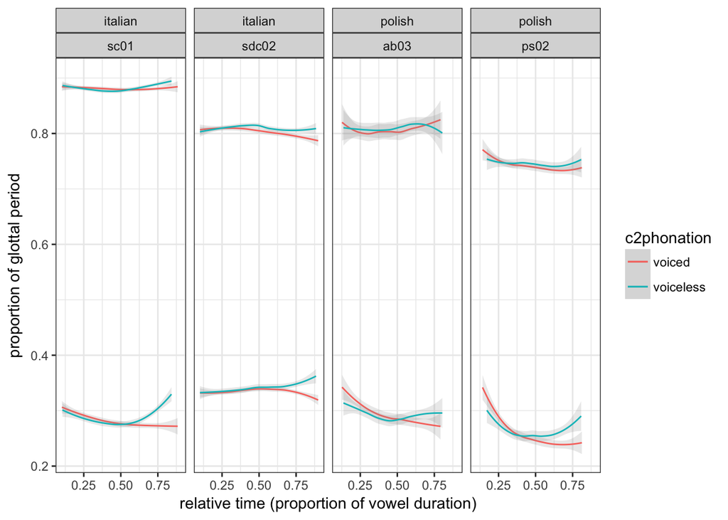

```r
ggplot(degg, aes(x = proportion, colour = c2phonation)) +
    facet_grid(. ~ language + speaker) +
    geom_smooth(aes(y = maximum), size = 0.5, alpha = 0.2) +
    geom_smooth(aes(y = minimum), size = 0.5, alpha = 0.2) +
    xlab("relative time (proportion of vowel duration)") +
    ylab("proportion of glottal period") +
    xlim(0.1, 0.9)
```

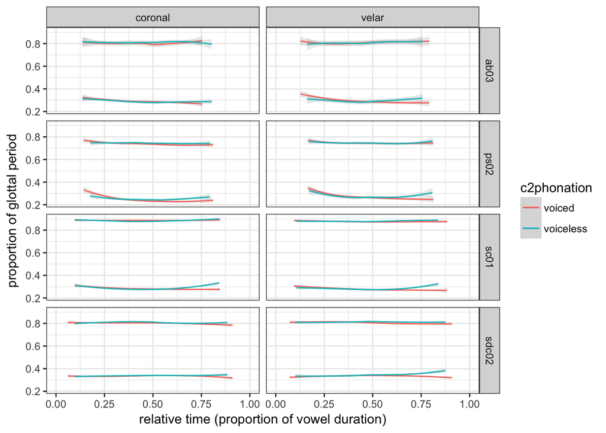

```r
ggplot(degg, aes(x = proportion, colour = c2phonation)) +
    facet_grid(speaker ~  c2place) +
    geom_smooth(aes(y = maximum), size = 0.5, alpha = 0.2) +
    geom_smooth(aes(y = minimum), size = 0.5, alpha = 0.2) +
    xlab("relative time (proportion of vowel duration)") +
    ylab("proportion of glottal period") +
    xlim(0, 1)
```

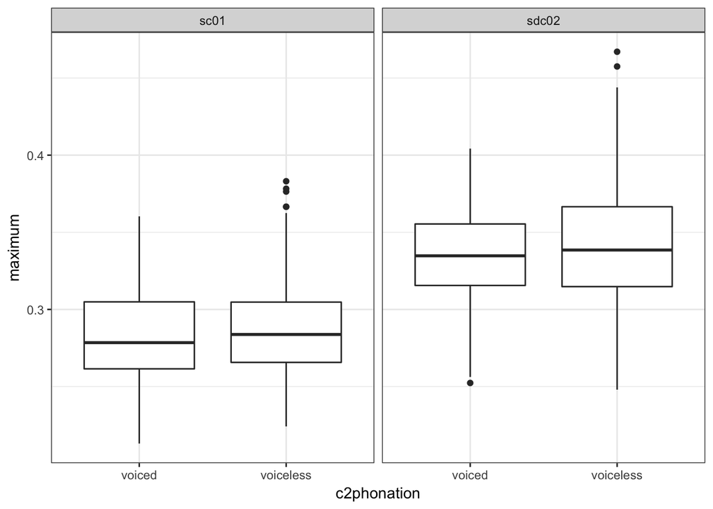

```r
ggplot(degg.it, aes(c2phonation, maximum)) +
    geom_boxplot() +
    facet_grid(. ~ speaker)
```

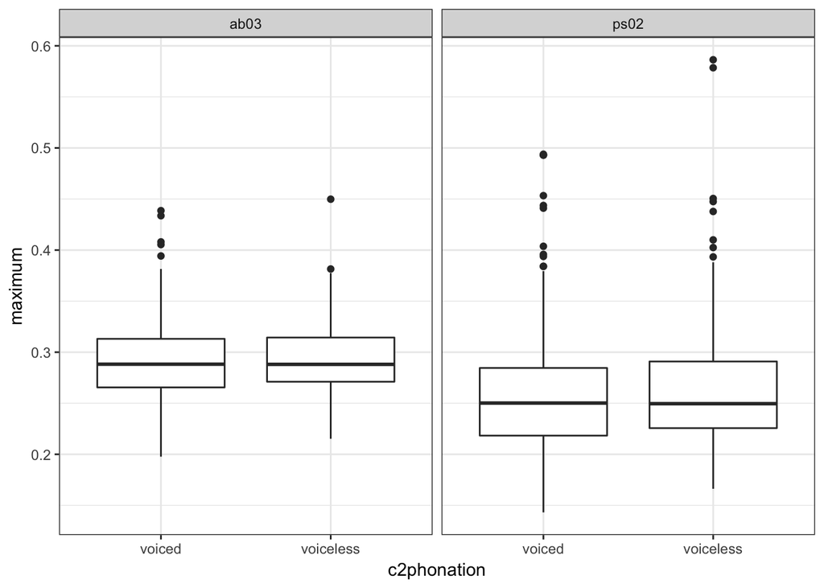

```r
ggplot(degg.pl, aes(c2phonation, maximum)) +
    geom_boxplot() +
    facet_grid(. ~ speaker)
```

As it can be seen from the graph, both Italian and Polish show a raising profile of the DEGG maxima in the voiceless condition in the second half of the vowel (Polish data are a bit more messy, but can still be interpreted this way).

# SSANOVA

## Italian

We can now calculate the SSANOVA model for dEGG maxima and minima.

```r
maximum.model <- ssanova(maximum ~ c2phonation + proportion + c2phonation:proportion,
data = degg.it)

minimum.model <- ssanova(minimum ~ c2phonation + proportion + c2phonation:proportion,
data = degg.it)
```

And calculate the predicted splines based on the SSANOVA models.

```r
predicted.degg <- expand.grid(proportion = seq(min(degg.it$proportion), max(degg.it$proportion),
                                         length = 100),
                    c2phonation = c("voiced", "voiceless"))

predicted.degg$maximum.fit <- predict(maximum.model, predicted.degg, se = TRUE)$fit
predicted.degg$maximum.SE <- predict(maximum.model, predicted.degg, se = TRUE)$se.fit
predicted.degg$minimum.fit <- predict(minimum.model, predicted.degg, se = TRUE)$fit
predicted.degg$minimum.SE <- predict(minimum.model, predicted.degg, se = TRUE)$se.fit
```

Finally, we can plot the predicted splines for Italian with 95% confidence levels for significance evaluation.

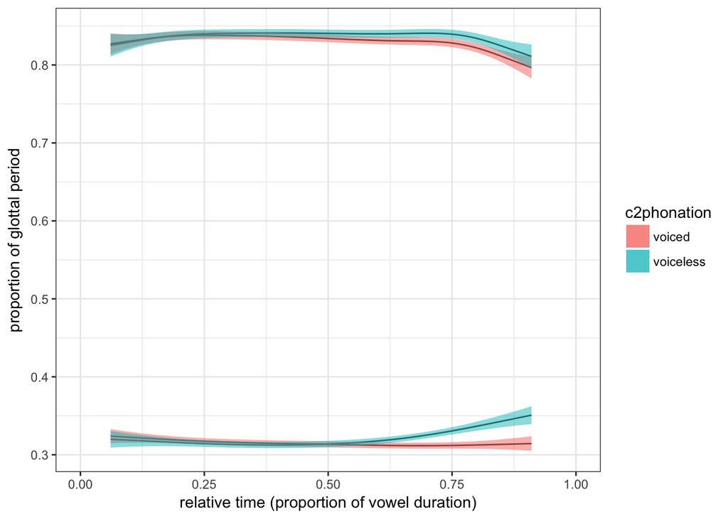

```r
ggplot(predicted.degg, aes(x = proportion, colour = c2phonation, group = c2phonation)) +
    geom_line(aes(y = maximum.fit), alpha = 1, colour = "grey20") +
    geom_ribbon(aes(ymin = maximum.fit-(1.96*maximum.SE),
                ymax = maximum.fit+(1.96*maximum.SE),
                fill = c2phonation ),alpha = 0.5,colour = "NA") +
    geom_line(aes(y = minimum.fit), alpha = 1, colour = "grey20") +
    geom_ribbon(aes(ymin = minimum.fit-(1.96*minimum.SE),
                    ymax = minimum.fit+(1.96*minimum.SE),
                    fill = c2phonation ),alpha = 0.5,colour = "NA") +
    xlab("relative time (proportion of vowel duration)") +
    ylab("proportion of glottal period") +
    xlim(0, 1)
```

## Polish

```r
maximum.model <- ssanova(maximum ~ c2phonation + proportion + c2phonation:proportion,
data = degg.pl)

minimum.model <- ssanova(minimum ~ c2phonation + proportion + c2phonation:proportion,
data = degg.pl)
```

And calculate the predicted splines based on the SSANOVA models.

```r
predicted.degg <- expand.grid(proportion = seq(min(degg.pl$proportion), max(degg.pl$proportion),
                                         length = 100),
                    c2phonation = c("voiced", "voiceless"))

predicted.degg$maximum.fit <- predict(maximum.model, predicted.degg, se = TRUE)$fit
predicted.degg$maximum.SE <- predict(maximum.model, predicted.degg, se = TRUE)$se.fit
predicted.degg$minimum.fit <- predict(minimum.model, predicted.degg, se = TRUE)$fit
predicted.degg$minimum.SE <- predict(minimum.model, predicted.degg, se = TRUE)$se.fit
```

Finally, we can plot the predicted splines for Polish with 95% confidence levels for significance evaluation.

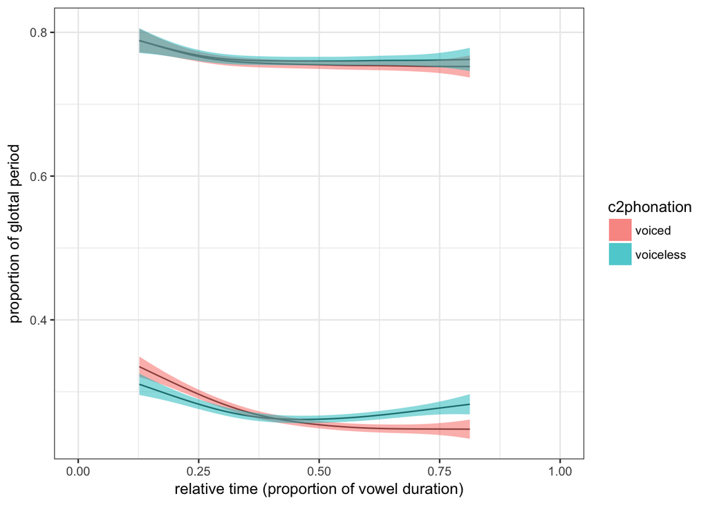

```r
ggplot(predicted.degg, aes(x = proportion, colour = c2phonation, group = c2phonation)) +
    geom_line(aes(y = maximum.fit), alpha = 1, colour = "grey20") +
    geom_ribbon(aes(ymin = maximum.fit-(1.96*maximum.SE),
                ymax = maximum.fit+(1.96*maximum.SE),
                fill = c2phonation ),alpha = 0.5,colour = "NA") +
    geom_line(aes(y = minimum.fit), alpha = 1, colour = "grey20") +
    geom_ribbon(aes(ymin = minimum.fit-(1.96*minimum.SE),
                    ymax = minimum.fit+(1.96*minimum.SE),
                    fill = c2phonation ),alpha = 0.5,colour = "NA") +
    xlab("relative time (proportion of vowel duration)") +
    ylab("proportion of glottal period") +
    xlim(0, 1)
```

# GAMM

## Italian

### Maximum

```r
degg.ord <- degg %>%
    filter(language == "italian") %>%
    mutate(c2phonation.ord = as.ordered(c2phonation))
contrasts(degg.ord$c2phonation.ord) <- "contr.treatment"

maximum.gam <- bam(
    maximum ~
        c2phonation.ord +
        s(proportion, bs = "cr") +
        s(proportion, by = c2phonation.ord, bs = "cr"),
    data = degg.ord,
    method = "ML"
)

summary(maximum.gam)
```

```
##
## Family: gaussian
## Link function: identity
##
## Formula:
## maximum ~ c2phonation.ord + s(proportion, bs = "cr") + s(proportion,
##     by = c2phonation.ord, bs = "cr")
##
## Parametric coefficients:
##                          Estimate Std. Error t value Pr(>|t|)
## (Intercept)              0.314838   0.001199 262.566  < 2e-16 ***
## c2phonation.ordvoiceless 0.004945   0.001787   2.767  0.00571 **
## ---
## Signif. codes:  0 '***' 0.001 '**' 0.01 '*' 0.05 '.' 0.1 ' ' 1
##
## Approximate significance of smooth terms:
##                                          edf Ref.df      F p-value
## s(proportion)                          1.010  1.019  5.041   0.025 *
## s(proportion):c2phonation.ordvoiceless 3.394  4.213 12.342 3.2e-10 ***
## ---
## Signif. codes:  0 '***' 0.001 '**' 0.01 '*' 0.05 '.' 0.1 ' ' 1
##
## R-sq.(adj) =  0.0286   Deviance explained = 3.12%
## -ML = -3579.3  Scale est. = 0.0015557  n = 1974
```

```r
maximum.gam.null <- bam(
    maximum ~
        s(proportion, bs = "cr"),
    data = degg.ord,
    method = "ML"
)

summary(maximum.gam.null)
```

```
##
## Family: gaussian
## Link function: identity
##
## Formula:
## maximum ~ s(proportion, bs = "cr")
##
## Parametric coefficients:
##              Estimate Std. Error t value Pr(>|t|)
## (Intercept) 0.3168534  0.0008974   353.1   <2e-16 ***
## ---
## Signif. codes:  0 '***' 0.001 '**' 0.01 '*' 0.05 '.' 0.1 ' ' 1
##
## Approximate significance of smooth terms:
##                 edf Ref.df     F p-value
## s(proportion) 2.704  3.376 4.338  0.0033 **
## ---
## Signif. codes:  0 '***' 0.001 '**' 0.01 '*' 0.05 '.' 0.1 ' ' 1
##
## R-sq.(adj) =  0.00722   Deviance explained = 0.858%
## -ML = -3558.1  Scale est. = 0.0015899  n = 1974
```

```r
compareML(maximum.gam, maximum.gam.null)
```

```
## maximum.gam: maximum ~ c2phonation.ord + s(proportion, bs = "cr") + s(proportion,
##     by = c2phonation.ord, bs = "cr")
##
## maximum.gam.null: maximum ~ s(proportion, bs = "cr")
##
## Chi-square test of ML scores
## -----
##              Model     Score Edf  Chisq    Df   p.value Sig.
## 1 maximum.gam.null -3558.106   3
## 2      maximum.gam -3579.311   6 21.204 3.000 3.285e-09  ***
##
## AIC difference: -39.62, model maximum.gam has lower AIC.
```

```
## Summary:
##  * c2phonation.ord : factor; set to the value(s): voiced, voiceless.
##  * proportion : numeric predictor; with 30 values ranging from 0.060916 to 0.910302.
```

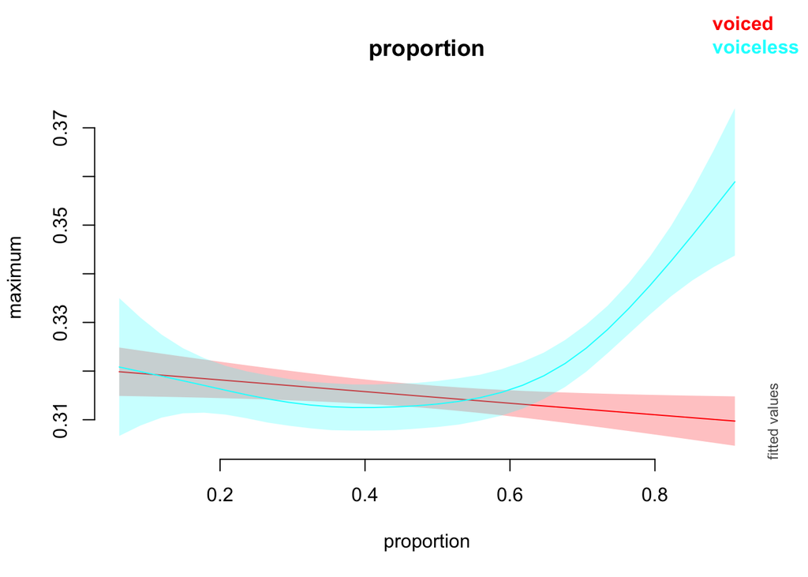

```r
plot_smooth(maximum.gam, view = "proportion", plot_all = "c2phonation.ord", rug = FALSE)
```

```
## Summary:
##  * proportion : numeric predictor; with 100 values ranging from 0.060916 to 0.910302.
```

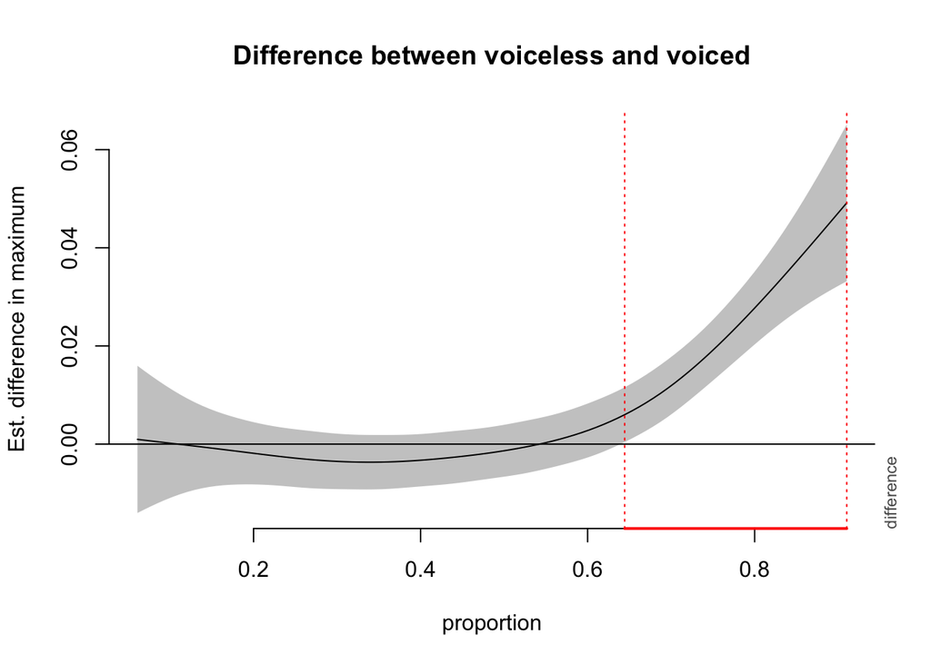

```
##
## proportion window(s) of significant difference(s):
##  0.644333 - 0.910302
```

```r
plot_diff(maximum.gam, view="proportion", comp = list(c2phonation.ord = c("voiceless","voiced")))
```

### Minimum

```r
minimum.gam <- bam(
    minimum ~
        c2phonation.ord +
        s(proportion, bs = "cr") +
        s(proportion, by = c2phonation.ord, bs = "cr"),
    data = degg.ord
)

summary(minimum.gam)
```

```
##
## Family: gaussian
## Link function: identity
##
## Formula:
## minimum ~ c2phonation.ord + s(proportion, bs = "cr") + s(proportion,
##     by = c2phonation.ord, bs = "cr")
##
## Parametric coefficients:
##                          Estimate Std. Error t value Pr(>|t|)
## (Intercept)              0.832126   0.001360 612.012  < 2e-16 ***
## c2phonation.ordvoiceless 0.006103   0.002026   3.012  0.00263 **
## ---
## Signif. codes:  0 '***' 0.001 '**' 0.01 '*' 0.05 '.' 0.1 ' ' 1
##
## Approximate significance of smooth terms:
##                                          edf Ref.df     F  p-value
## s(proportion)                          5.003    6.1 6.173 1.56e-06 ***
## s(proportion):c2phonation.ordvoiceless 1.000    1.0 4.331   0.0375 *
## ---
## Signif. codes:  0 '***' 0.001 '**' 0.01 '*' 0.05 '.' 0.1 ' ' 1
##
## R-sq.(adj) =  0.0233   Deviance explained = 2.68%
## fREML = -3313.8  Scale est. = 0.0019945  n = 1974
```

```
## Summary:
##  * c2phonation.ord : factor; set to the value(s): voiced, voiceless.
##  * proportion : numeric predictor; with 30 values ranging from 0.060916 to 0.910302.
```

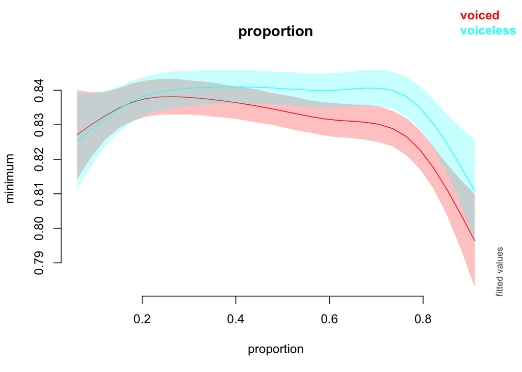

```r
plot_smooth(minimum.gam, view = "proportion", plot_all = "c2phonation.ord", rug = FALSE)
```

```
## Summary:
##  * proportion : numeric predictor; with 100 values ranging from 0.060916 to 0.910302.
```

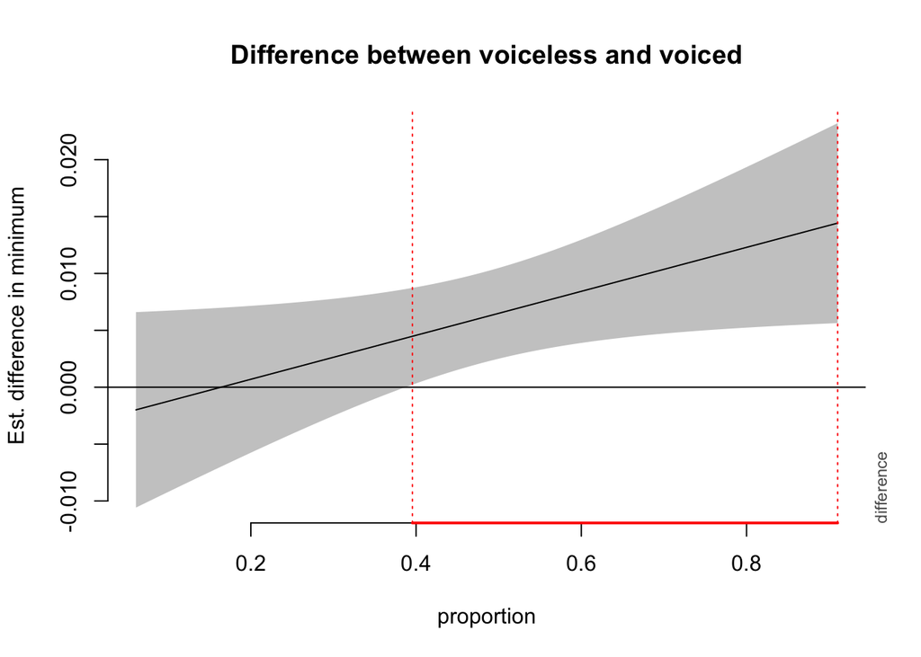

```
##
## proportion window(s) of significant difference(s):
##  0.395523 - 0.910302
```

```r
plot_diff(minimum.gam, view="proportion", comp = list(c2phonation.ord = c("voiceless","voiced")))
```

# GAMM

## Polish

### Maximum

```r
degg.ord <- degg %>%
    filter(language == "polish") %>%
    mutate(c2phonation.ord = as.ordered(c2phonation))
contrasts(degg.ord$c2phonation.ord) <- "contr.treatment"

maximum.gam <- bam(
    maximum ~
        c2phonation.ord +
        s(proportion, bs = "cr") +
        s(proportion, by = c2phonation.ord, bs = "cr"),
    data = degg.ord,
    method = "ML"
)

summary(maximum.gam)
```

```
##
## Family: gaussian
## Link function: identity
##
## Formula:
## maximum ~ c2phonation.ord + s(proportion, bs = "cr") + s(proportion,
##     by = c2phonation.ord, bs = "cr")
##
## Parametric coefficients:
##                          Estimate Std. Error t value Pr(>|t|)
## (Intercept)              0.265395   0.001802 147.255   <2e-16 ***
## c2phonation.ordvoiceless 0.005321   0.002630   2.023   0.0433 *
## ---
## Signif. codes:  0 '***' 0.001 '**' 0.01 '*' 0.05 '.' 0.1 ' ' 1
##
## Approximate significance of smooth terms:
##                                          edf Ref.df     F  p-value
## s(proportion)                          3.885  4.816 34.51  < 2e-16 ***
## s(proportion):c2phonation.ordvoiceless 1.001  1.002 30.42 4.05e-08 ***
## ---
## Signif. codes:  0 '***' 0.001 '**' 0.01 '*' 0.05 '.' 0.1 ' ' 1
##
## R-sq.(adj) =  0.109   Deviance explained = 11.3%
## -ML = -2224.7  Scale est. = 0.0023989  n = 1394
```

```r
maximum.gam.null <- bam(
    maximum ~
        s(proportion, bs = "cr"),
    data = degg.ord,
    method = "ML"
)

summary(maximum.gam.null)
```

```
##
## Family: gaussian
## Link function: identity
##
## Formula:
## maximum ~ s(proportion, bs = "cr")
##
## Parametric coefficients:
##             Estimate Std. Error t value Pr(>|t|)
## (Intercept) 0.267899   0.001327   201.9   <2e-16 ***
## ---
## Signif. codes:  0 '***' 0.001 '**' 0.01 '*' 0.05 '.' 0.1 ' ' 1
##
## Approximate significance of smooth terms:
##                 edf Ref.df     F p-value
## s(proportion) 3.931  4.871 27.78  <2e-16 ***
## ---
## Signif. codes:  0 '***' 0.001 '**' 0.01 '*' 0.05 '.' 0.1 ' ' 1
##
## R-sq.(adj) =  0.0881   Deviance explained = 9.06%
## -ML = -2207.5  Scale est. = 0.0024547  n = 1394
```

```r
compareML(maximum.gam, maximum.gam.null)
```

```
## maximum.gam: maximum ~ c2phonation.ord + s(proportion, bs = "cr") + s(proportion,
##     by = c2phonation.ord, bs = "cr")
##
## maximum.gam.null: maximum ~ s(proportion, bs = "cr")
##
## Chi-square test of ML scores
## -----
##              Model     Score Edf  Chisq    Df   p.value Sig.
## 1 maximum.gam.null -2207.529   3
## 2      maximum.gam -2224.652   6 17.123 3.000 1.757e-07  ***
##
## AIC difference: -30.17, model maximum.gam has lower AIC.
```

```
## Summary:
##  * c2phonation.ord : factor; set to the value(s): voiced, voiceless.
##  * proportion : numeric predictor; with 30 values ranging from 0.126844 to 0.812556.
```

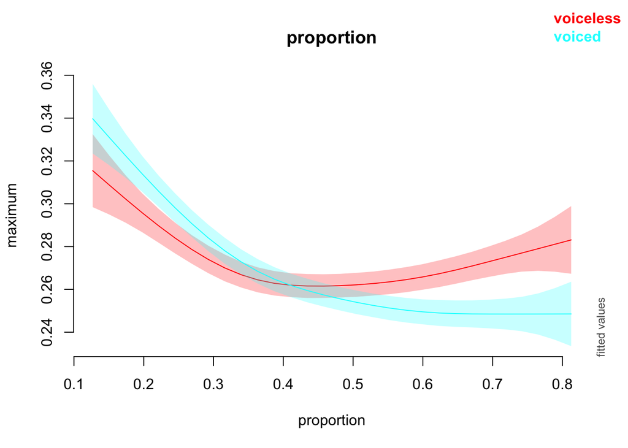

```r
plot_smooth(maximum.gam, view = "proportion", plot_all = "c2phonation.ord", rug = FALSE)
```

```
## Summary:
##  * proportion : numeric predictor; with 100 values ranging from 0.126844 to 0.812556.
```

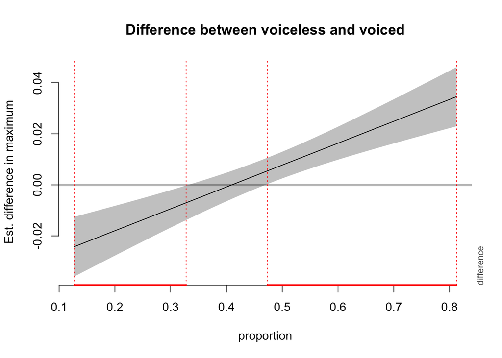

```
##
## proportion window(s) of significant difference(s):
##  0.126844 - 0.327709
##  0.473163 - 0.812556
```

```r
plot_diff(maximum.gam, view="proportion", comp = list(c2phonation.ord = c("voiceless","voiced")))
```

### Minimum

```r
minimum.gam <- bam(
    minimum ~
        c2phonation.ord +
        s(proportion, bs = "cr") +
        s(proportion, by = c2phonation.ord, bs = "cr"),
    data = degg.ord
)

summary(minimum.gam)
```

```
##
## Family: gaussian
## Link function: identity
##
## Formula:
## minimum ~ c2phonation.ord + s(proportion, bs = "cr") + s(proportion,
##     by = c2phonation.ord, bs = "cr")
##
## Parametric coefficients:
##                          Estimate Std. Error t value Pr(>|t|)
## (Intercept)              0.757879   0.001988 381.132   <2e-16 ***
## c2phonation.ordvoiceless 0.004850   0.002902   1.671   0.0949 .
## ---
## Signif. codes:  0 '***' 0.001 '**' 0.01 '*' 0.05 '.' 0.1 ' ' 1
##
## Approximate significance of smooth terms:
##                                          edf Ref.df     F p-value
## s(proportion)                          3.252  4.055 3.962 0.00359 **
## s(proportion):c2phonation.ordvoiceless 1.000  1.000 0.731 0.39261
## ---
## Signif. codes:  0 '***' 0.001 '**' 0.01 '*' 0.05 '.' 0.1 ' ' 1
##
## R-sq.(adj) =  0.0127   Deviance explained = 1.64%
## fREML = -2072.4  Scale est. = 0.0029204  n = 1394
```

```
## Summary:
##  * c2phonation.ord : factor; set to the value(s): voiced, voiceless.
##  * proportion : numeric predictor; with 30 values ranging from 0.126844 to 0.812556.
```

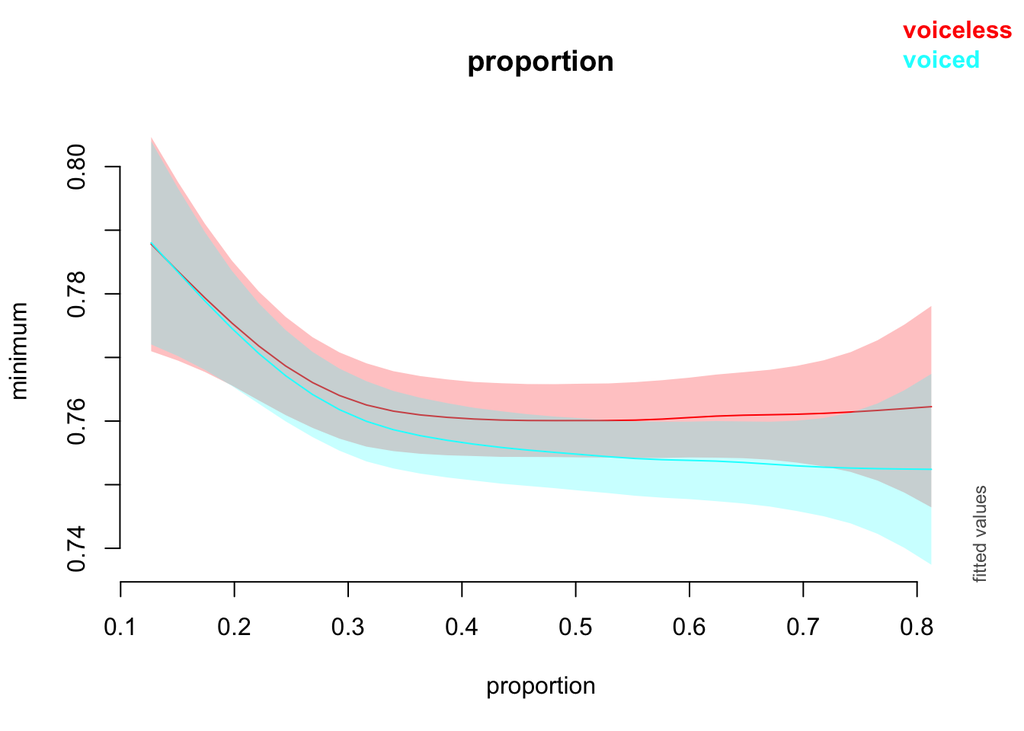

```r
plot_smooth(minimum.gam, view = "proportion", plot_all = "c2phonation.ord", rug = FALSE)
```

```
## Summary:
##  * proportion : numeric predictor; with 100 values ranging from 0.126844 to 0.812556.
```

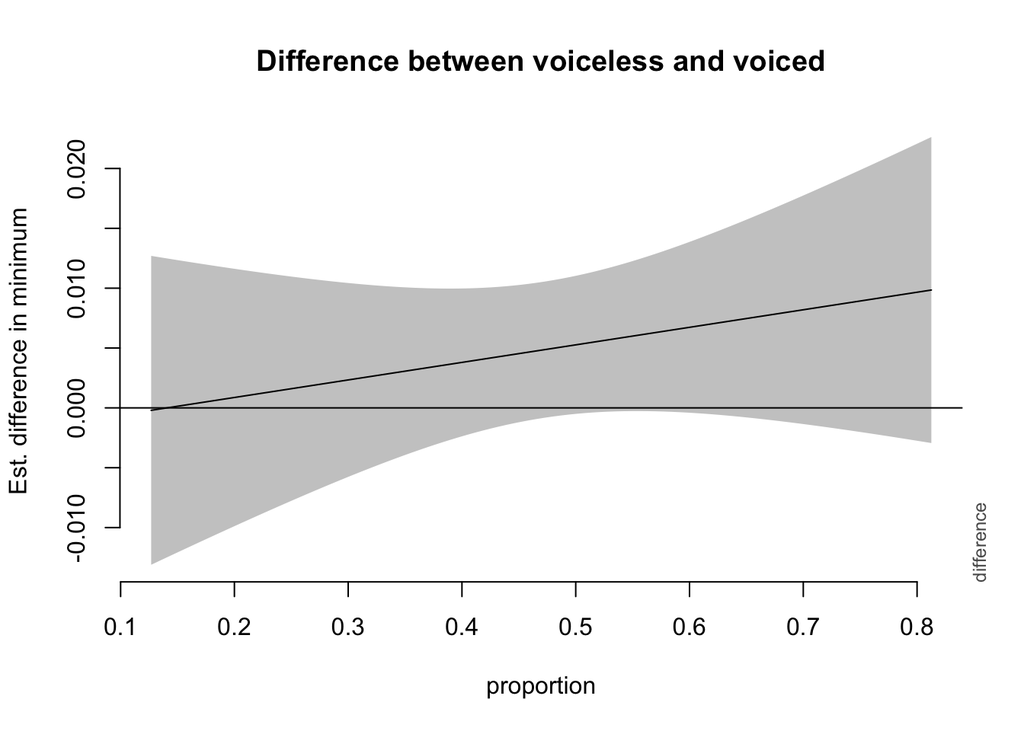

```
##
## Difference is not significant.
```

```r
plot_diff(minimum.gam, view="proportion", comp = list(c2phonation.ord = c("voiceless","voiced")))
```